# Intro to ggplot2

## Scatter Plot

Next we’ll make that scatter plot again. We’ll map `tension` to the x-axis and `satisfaction` to the y-axis. Then we’ll add `geom_point()`.

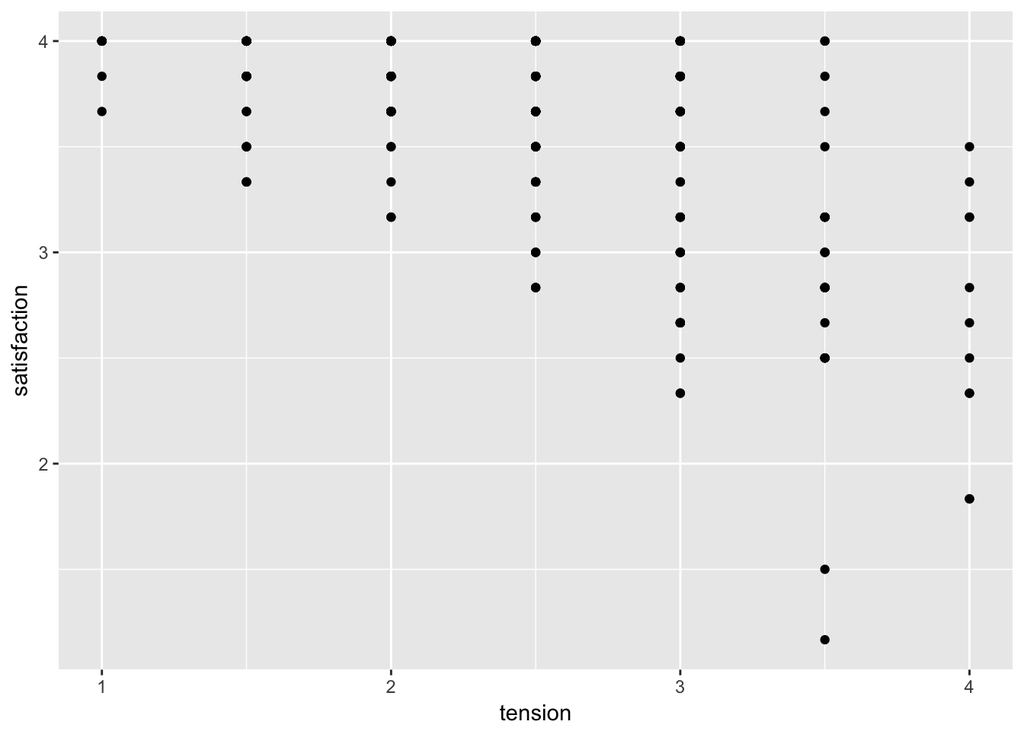

```r
ggplot(acitelli, aes(x = tension, y = satisfaction)) +
  geom_point()
```

Why does it appear as though there is far less data than there really is? Check out the plot when we use `geom_jitter()`. What do you think `geom_jitter()` does?

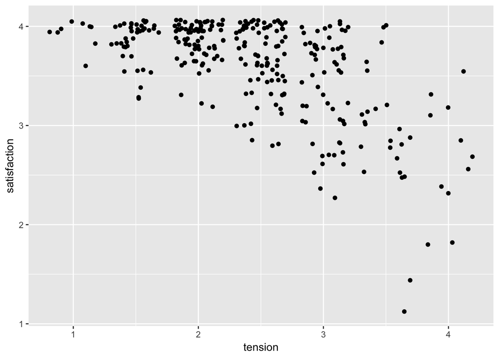

```r
ggplot(acitelli, aes(x = tension, y = satisfaction)) +
  geom_jitter()
```

We can add more than one geom. To the jittered scatter plot we can add a least squares regression line with `geom_smooth()`. Inside of geom smooth we need to specific `method = "lm"`, the lm stand for *linear model*. We can also turn off the standard errors with se = 0.

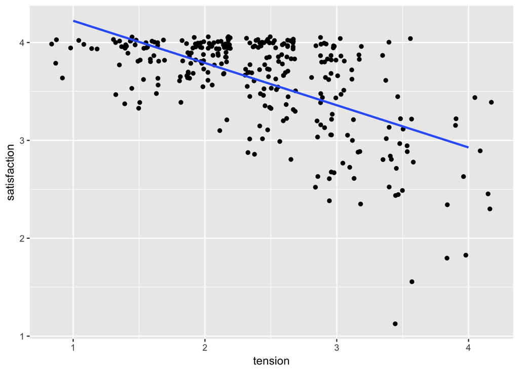

```r
ggplot(acitelli, aes(x = tension, y = satisfaction)) +
  geom_jitter() +
  geom_smooth(method = "lm", se = 0)
```

Again, we can map gender to the color aesthetic.

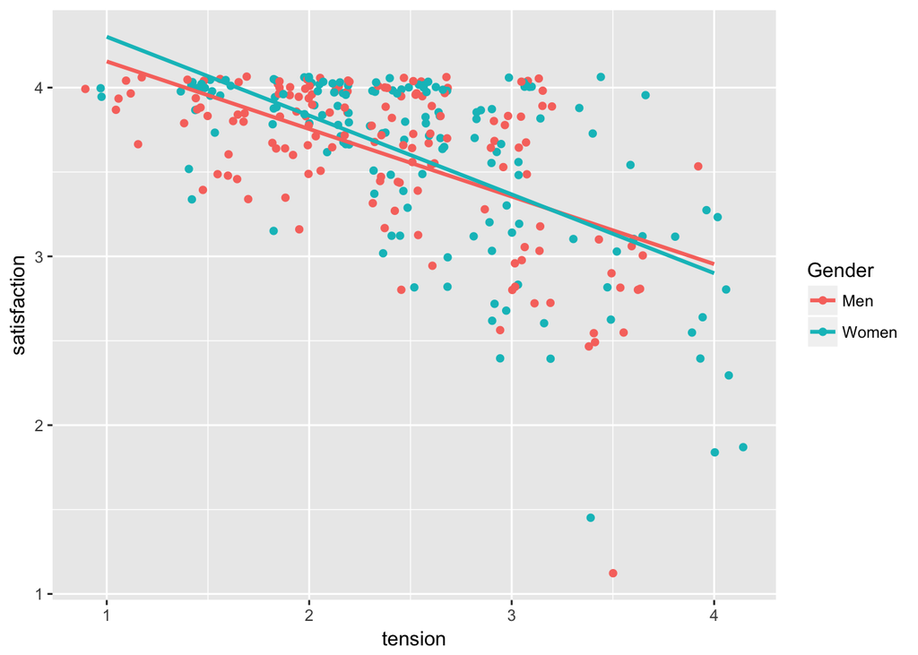

```r
ggplot(acitelli, aes(x = tension, y = satisfaction, color = Gender)) +
  geom_jitter() +
  geom_smooth(method = "lm", se = 0)
```

Or use `facet_wrap()`.

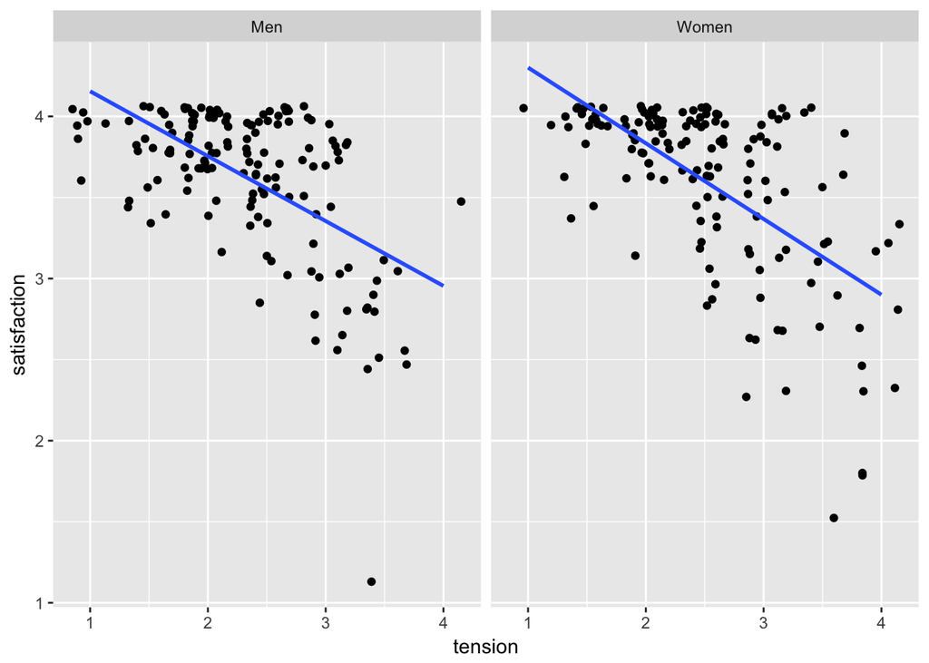

```r
ggplot(acitelli, aes(x = tension, y = satisfaction)) +
  geom_jitter() +
  geom_smooth(method = "lm", se = 0) +
  facet_wrap(~Gender)
```

## Labels and Colors

We can create a plot object with the `<-` symbol. Then to print the plot we’d need to run a line with the name of our plot.

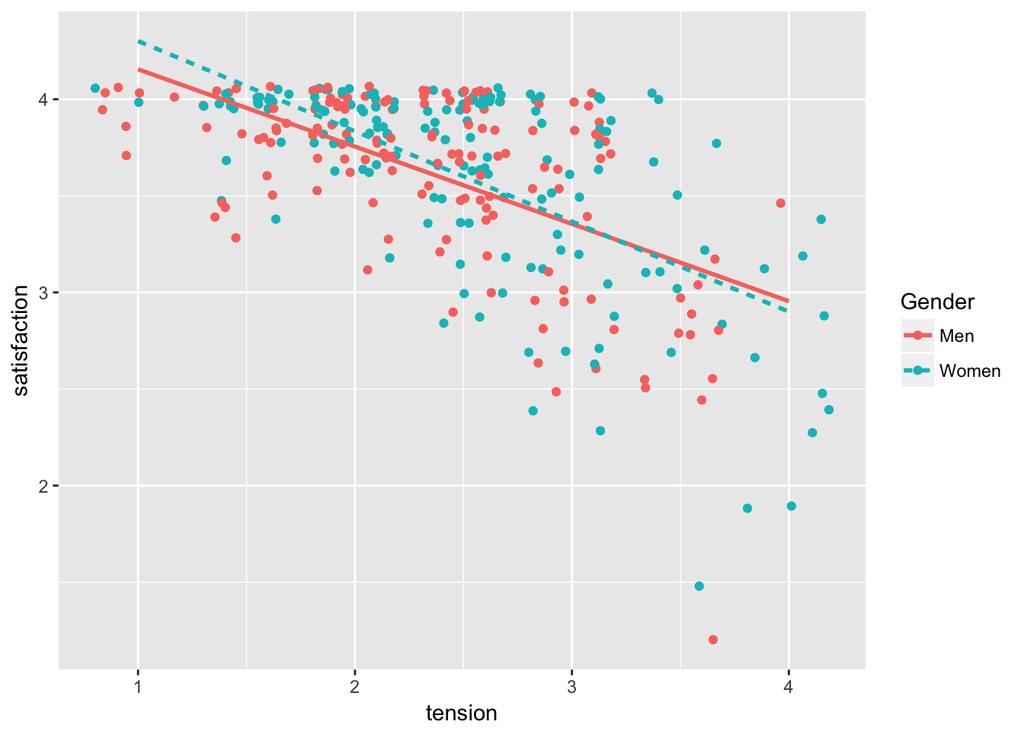

```r
myplot <- ggplot(acitelli, aes(x = tension, y = satisfaction, color = Gender, linetype = Gender)) +
  geom_jitter() +
  geom_smooth(method = "lm", se = 0)

myplot
```

Then, we can add to that plot object. We can add x labels, x labels, change the colors, and the theme. There is much more that you can do with `ggplot2`!

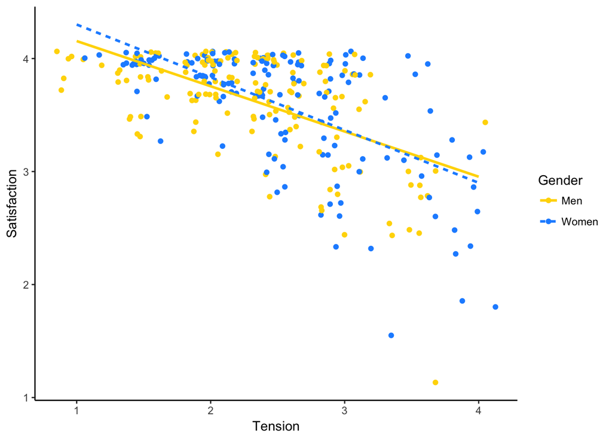

```r
myplot +
  xlab("Tension") +
  ylab("Satisfaction") +
  scale_color_manual(values = c("gold", "dodgerblue")) +
  theme_classic()
```